# eds221-day8-activities

Javier Patron

2022-08-17

```r
library(tidyverse)
library(here)
library(paletteer)
library(janitor)
library(skimr)
library(ggrepel)
```

```r
space_launches <- read_csv(here::here("data", "space_launches.csv"))
```

## Make the ugliest graph possible

Some ideas:

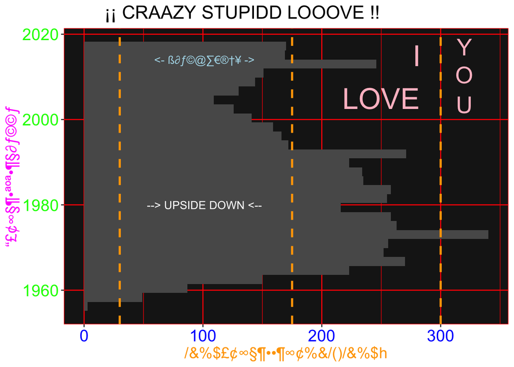

```r
d_love_graph <- ggplot(space_launches, aes(y = launch_year)) +
  geom_histogram() +
  labs(title = "        ¡¡ CRAAZY STUPIDD LOOOVE !!",
       x = "/&%$£¢∞§¶••¶∞¢%&/()/&%$h",
       y = "“£¢∞§¶•ªºª•¶§∂ƒ©©ƒ") +
  theme(panel.grid = element_line(color = "red"),
        panel.grid.minor.y = element_blank(),
        axis.title.x = element_text(color = "orange"),
        axis.title.y = element_text(color = "magenta"),
        axis.text.y = element_text(color = "green"),
        axis.text.x = element_text(color = "blue"),
        text = element_text (size = 20),
        title = element_text(size = 15),
        panel.background = element_rect(color = "red", fill = "gray10")) +
  annotate("text", x = 100, y = 2014, label = " <- ß∂ƒ©@∑€®†¥ ->", color = "lightblue") +
  annotate("text", x = 100, y = 1980, label = " --> UPSIDE DOWN <--", color = "white") +
  annotate("text", x = 250, y = 2005, label = " LOVE ", color = "pink", size = 10) +
  annotate("text", x = 280, y = 2015, label = " I ", color = "pink", size = 10) +
  annotate("text", x = 320, y = 2017, label = " Y ", color = "pink", size = 8) +
  annotate("text", x = 320, y = 2010.5, label = " O ", color = "pink", size = 8) +
  annotate("text", x = 320, y = 2003.5, label = " U ", color = "pink", size = 8) +
  geom_vline(xintercept = 30, linetype = "dashed", color = "orange", size = 1) +
  geom_vline(xintercept = 175, linetype = "dashed", color = "orange", size = 1) +
  geom_vline(xintercept = 300, linetype = "dashed", color = "orange", size = 1)

d_love_graph
```

```r
ggsave(plot = d_love_graph , here::here("data", "love.jpg"))
```

graph #2

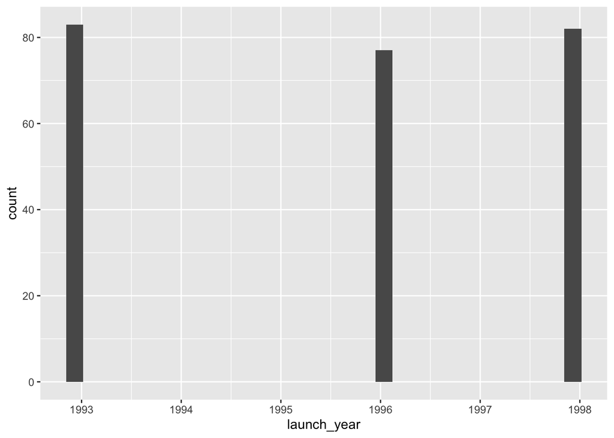

```r
ggplot(space_launches, aes(x = launch_year)) +
  geom_histogram(data = subset(space_launches, launch_year == 1993, fill="red")) +
  geom_histogram(data = subset(space_launches, launch_year == 1996, fill="orange")) +
  geom_histogram(data = subset(space_launches, launch_year == 1998, fill="green"))
```

Task 2: Wrangling practice with the SF Greenhouse Gas data Download the San_Francisco_Communitywide_Greenhouse_Gas_Inventory.csv file (I’ll put this in Slack). Information about the data is available here.

```r
san_francisco <- read_csv(here::here("data", "San_Francisco_Communitywide_Greenhouse_Gas_Inventory.csv")) |>
  clean_names()
sf_summary <- san_francisco |>
  group_by(sector_general) |>
  summarize(tot_annual = sum(emissions_mt_co2e, na.rm = TRUE))
```

Read in the SF emissions dataset, then complete the following:

Create a summary table of total annual greenhouse gas emissions (only from Emissions_mtCO2e column) by sector_general

Create a summary table of total annual greenhouse gas emissions (only from Emissions_mtCO2e column) by year and commodity type

Create a subset of the data that only contains observations from 2005 on, only for observations where Sector_Detail2 contains the pattern “PG&E”, then limit to columns Calendar_Year, Sector_Detail2 and Emissions_mtCO2e.

```r
sf_filter <- san_francisco |>
  filter(calendar_year %in% 2005:2019,
         str_detect(sector_detail2, pattern = "PG&E")) |>
  select(cols= c("calendar_year", "sector_detail2", "emissions_mt_co2e"))
```

Task 3: Do your data viz best Create a finalized graph (as perfect as you can make it) using the San Francisco GHG emissions dataset. You get to choose what you want to visualize. You can pick which variables & observations you’re interested in. You may want to do some wrangling / summarizing first.

Once you’ve decided on what to plot, create the best graph that you can to communicate what’s going on with the data.

Once you’re done, drop your best graph (as a .png or .jpg) into the course Slack channel.

```r
skim(san_francisco)
```

Data summary

| Name | san_francisco |
| --- | --- |
| Number of rows | 685 |
| Number of columns | 11 |
| _______________________ |  |
| Column type frequency: |  |
| character | 7 |
| numeric | 4 |
| ________________________ |  |
| Group variables | None |

**Variable type: character**

| skim_variable | n_missing | complete_rate | min | max | empty | n_unique | whitespace |
| --- | --- | --- | --- | --- | --- | --- | --- |
| sector_general | 0 | 1 | 9 | 19 | 0 | 6 | 0 |
| sector_detail1 | 0 | 1 | 11 | 36 | 0 | 14 | 0 |
| sector_detail2 | 1 | 1 | 4 | 91 | 0 | 45 | 0 |
| sector_gpc | 0 | 1 | 5 | 40 | 0 | 4 | 0 |
| sector_gpc_detail | 0 | 1 | 4 | 55 | 0 | 20 | 0 |
| commodity_type | 0 | 1 | 2 | 30 | 0 | 20 | 0 |
| quantity_units | 0 | 1 | 3 | 11 | 0 | 9 | 0 |

**Variable type: numeric**

| skim_variable | n_missing | complete_rate | mean | sd | p0 | p25 | p50 | p75 | p100 | hist |
| --- | --- | --- | --- | --- | --- | --- | --- | --- | --- | --- |
| calendar_year | 0 | 1.00 | 2010.47 | 8.81 | 1990 | 2005.00 | 2015.00 | 2017.00 | 2.019000e+03 | ▂▂▂▃▇ |
| emissions_mt_co2e | 5 | 0.99 | 91352.07 | 269109.73 | 0 | 3.26 | 1261.41 | 57023.88 | 2.205904e+06 | ▇▁▁▁▁ |
| biogenic_emissions_mt_co2e | 2 | 1.00 | 643.88 | 3739.87 | 0 | 0.00 | 0.00 | 0.00 | 4.211469e+04 | ▇▁▁▁▁ |
| quantity | 0 | 1.00 | 154447811.89 | 599978794.54 | 0 | 0.00 | 375112.62 | 8635124.17 | 4.181776e+09 | ▇▁▁▁▁ |

```r
sf_commodity <- san_francisco |>
  group_by(commodity_type) |>
  summarize(co2 = sum(emissions_mt_co2e, na.rm = TRUE))

sf_ <- san_francisco |>
  group_by(sector_gpc, calendar_year) |>
  summarize(co2 = sum(emissions_mt_co2e, na.rm = TRUE),
            bio_co2 = sum(biogenic_emissions_mt_co2e, na.rm = TRUE),
            quantity = sum(quantity),
            units = unique(quantity_units)) |>
  mutate(co2_trillion = co2 /1000000)
sf_[sf_ == "Agriculture, Forestry and Other Land Use"] <- "Land Use"
```

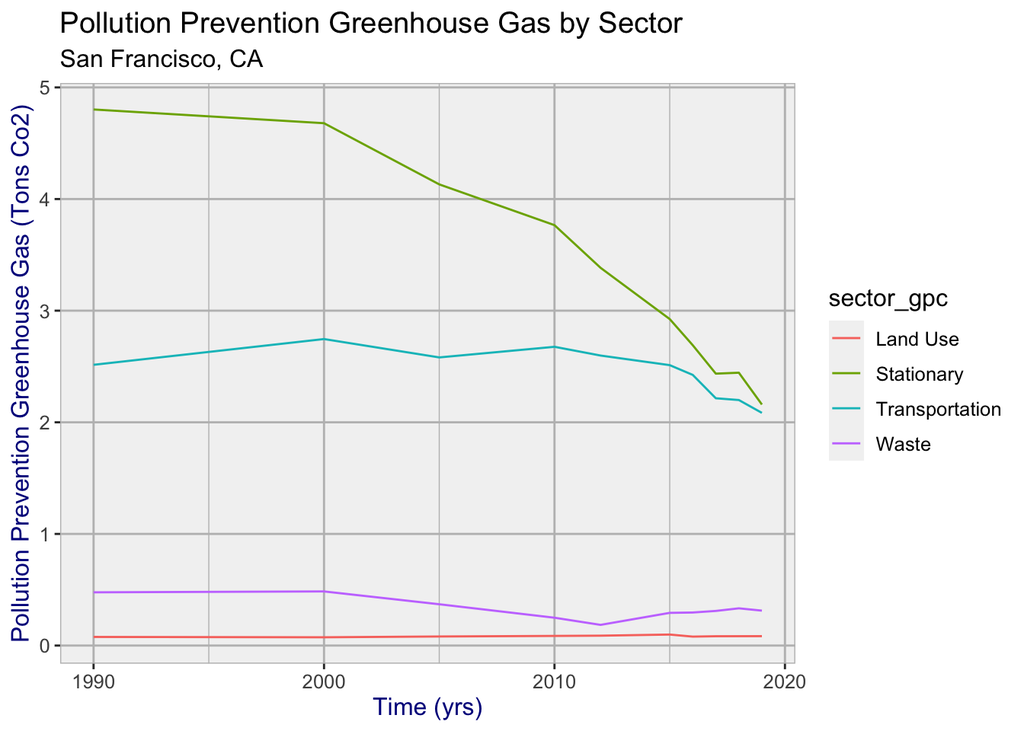

```r
sf_line <- ggplot(sf_, aes(x = calendar_year, y = co2_trillion)) +
  geom_line(aes(color = sector_gpc)) +
  labs (title = "Pollution Prevention Greenhouse Gas by Sector" ,
        subtitle = "San Francisco, CA ",
        x = "Time (yrs)",
        y = "Pollution Prevention Greenhouse Gas (Tons Co2)") +
    theme(panel.grid = element_line(color = "gray"),
        panel.grid.minor.y = element_blank(),
        axis.title = element_text(color = "darkblue"),
        text = element_text (size = 12),
        panel.background = element_rect(color = "gray", fill = "gray95"))

sf_line
```

```r
ggsave(plot = sf_line, here::here("data", "GHG.jpg"))
```